# Chapter 4 Show the Right Numbers

```r
library(dplyr)
library(magrittr)
library(socviz)
library(gapminder)
library(tibble)
library(readr)
library(ggplot2)
library(scales)
```

## 4.2 Grouped data and the “Group” aesthetic

Plot the gapminder data grouped by country across the years with a line chart:

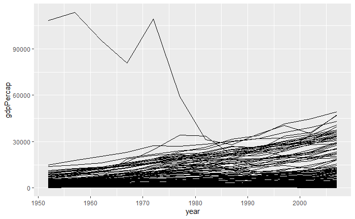

```r
ggplot(gapminder, aes(year, gdpPercap)) +
  geom_line(aes(group = country))
```

## 4.3 Facet to make small multiples

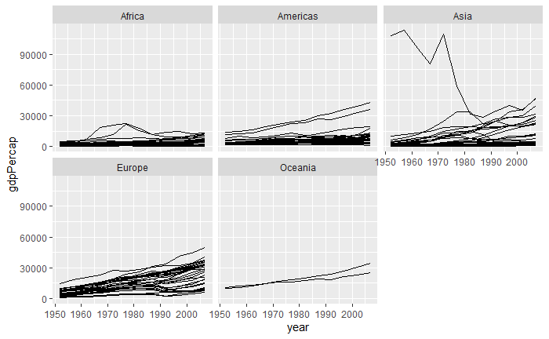

```r
ggplot(gapminder, aes(year, gdpPercap)) +
  geom_line(aes(group = country)) +
  facet_wrap(~continent)
```

Enhanced facet:

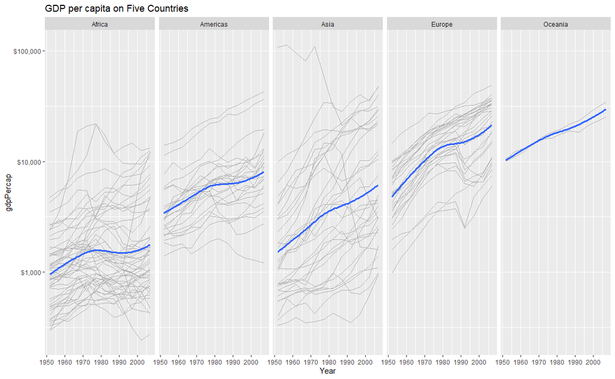

```r
ggplot(gapminder, aes(year, gdpPercap)) +
  geom_line(color = "gray70", aes(group = country)) +
  geom_smooth(size = 1.1, method = stats::loess, se = FALSE) +
  scale_y_log10(labels = scales::dollar) +
  facet_wrap(~continent, ncol = 5) +
  labs(
    x = "Year",
    title = "GDP per capita on Five Countries"
  )
```

Using the dataset ‘gss_sm’

```r
glimpse(gss_sm)
```

```
Observations: 2,867
Variables: 32
$ year        <dbl> 2016, 2016, 2016, 2016, 2016, 2016, 2016, 2016, 2016, 2016, 2016, 2016, 2016, 2016, 201...
$ id          <dbl> 1, 2, 3, 4, 5, 6, 7, 8, 9, 10, 11, 12, 13, 14, 15, 16, 17, 18, 19, 20, 21, 22, 23, 24, ...
$ ballot      <dbl> 1, 2, 3, 1, 3, 2, 1, 3, 1, 3, 2, 1, 2, 3, 2, 3, 3, 2, 2, 1, 2, 3, 2, 3, 3, 2, 1, 2, 2, ...
$ age         <dbl> 47, 61, 72, 43, 55, 53, 50, 23, 45, 71, 33, 86, 32, 60, 76, 33, 56, 62, 31, 43, 58, 32,...
$ childs      <dbl> 3, 0, 2, 4, 2, 2, 2, 3, 3, 4, 5, 4, 3, 5, 7, 2, 6, 5, 0, 2, 0, 3, 2, 2, 2, 8, 2, 0, 2, ...
$ sibs        <dbl> 2, 3, 3, 3, 2, 2, 2, 6, 5, 1, 4, 4, 3, 6, 0, 1, 3, 8, 2, 0, 1, 4, 2, 2, 2, 7, 1, 0, 1, ...
$ degree      <fct> Bachelor, High School, Bachelor, High School, Graduate, Junior College, High School, Hi...
$ race        <fct> White, White, White, White, White, White, White, Other, Black, White, Black, White, Bla...
$ sex         <fct> Male, Male, Male, Female, Female, Female, Male, Female, Male, Male, Female, Female, Mal...
$ region      <fct> New England, New England, New England, New England, New England, New England, New Engla...
$ income16    <fct> $170000 or over, $50000 to 59999, $75000 to $89999, $170000 or over, $170000 or over, $...
$ relig       <fct> None, None, Catholic, Catholic, None, None, None, Catholic, Protestant, None, Protestan...
$ marital     <fct> Married, Never Married, Married, Married, Married, Married, Married, Married, Married, ...
```

[output cut: 19 more lines]

Faceting gss_sm by sex and race

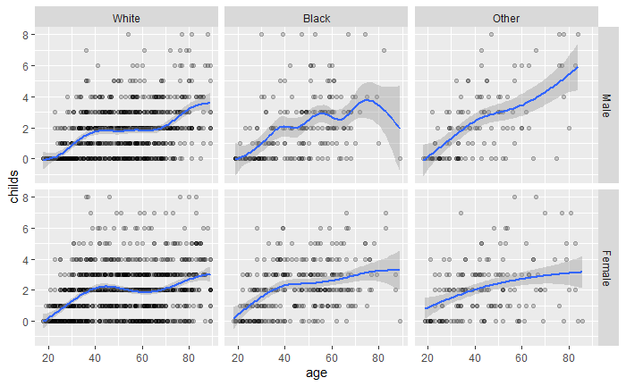

```r
ggplot(gss_sm, aes(age, childs)) +
  geom_point(alpha = 0.2) +
  geom_smooth() +
  facet_grid(sex ~ race)
```

## 4.4 Geoms can transform data

Specify ‘group = 1’ when we want to total number of observations to compute a proportion (i.e. ..prop..)

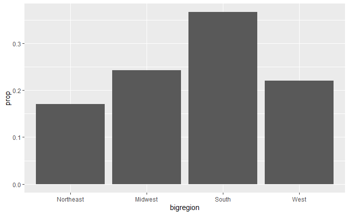

```r
ggplot(gss_sm, aes(bigregion)) +
  geom_bar(aes(y = ..prop.., group = 1))
```

What is the religious preference?

```r
table(gss_sm$religion)
```

```
Protestant   Catholic     Jewish       None      Other
      1371        649         51        619        159
```

Mapping two aesthetics to the same variable without the ledgend:

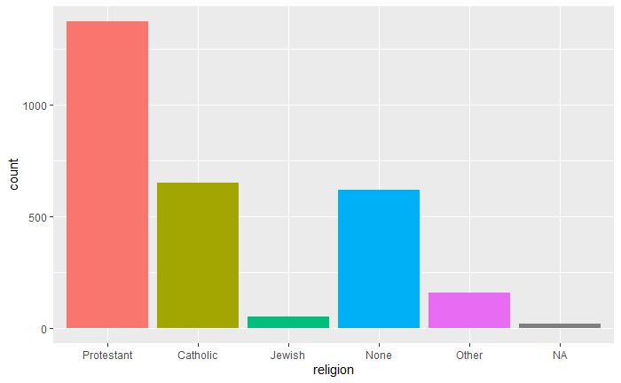

```r
ggplot(gss_sm, aes(x = religion, fill = religion)) +
  geom_bar() +
  guides(fill = FALSE)
```

## 4.5 Frequency plots the slightly awkward way

The distributions of religions across different regions of US - the ‘religion’ variable broken down proportionally within ‘bigregion’ (the default plot is a stacked bar chart):

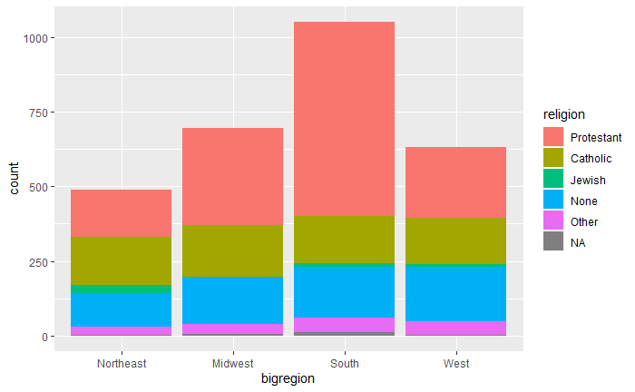

```r
ggplot(gss_sm, aes(x = bigregion, fill = religion)) +
  geom_bar()
```

Using ‘position’ = “dodge” the y axis reverts back to count:

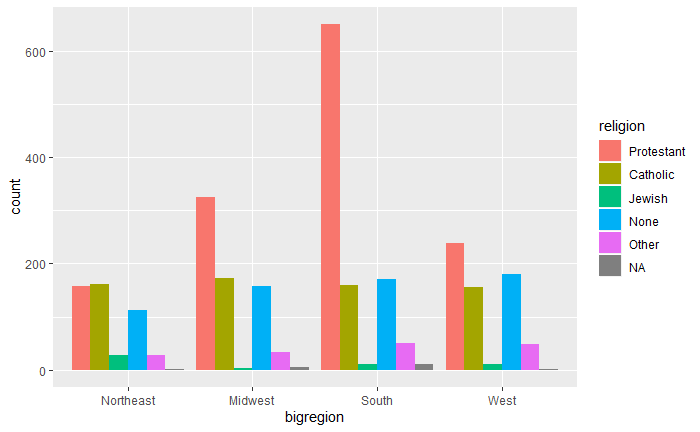

```r
ggplot(gss_sm, aes(x = bigregion, fill = religion)) +
  geom_bar(position = "dodge")
```

Using ‘..prop..’:

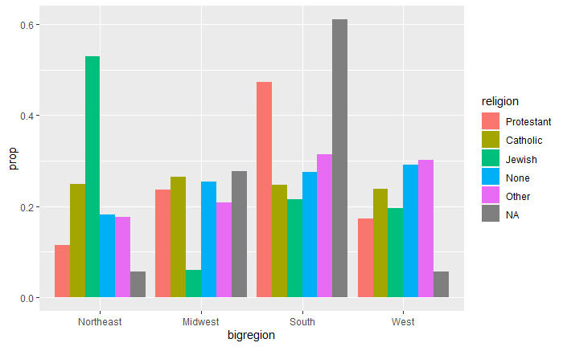

```r
ggplot(gss_sm, aes(x = bigregion, fill = religion)) +
  geom_bar(position = "dodge", aes(y = ..prop.., group = religion))
```

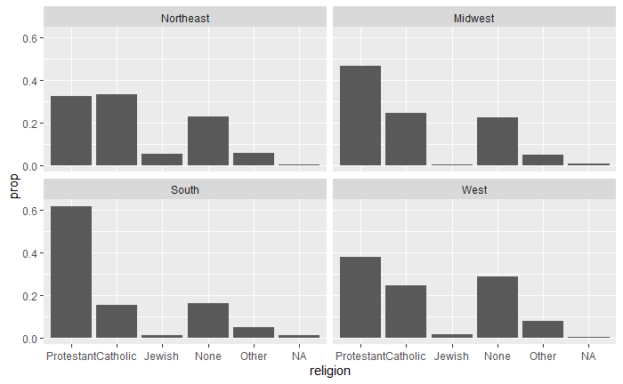

```r
ggplot(gss_sm, aes(x = religion)) +
  geom_bar(position = "dodge", aes(y = ..prop.., group = bigregion)) +
  facet_wrap(~bigregion, ncol = 2)
```

Using the ‘dplyr’ first before plotting will make the above attempts easier.

## 4.6 Histograms and density plots

A histogram chops a continuous variable into bins. geom_histogram will compute the bins for us. Looking at a histogram of continuous variable ‘area’ from dataset ‘midwest’:

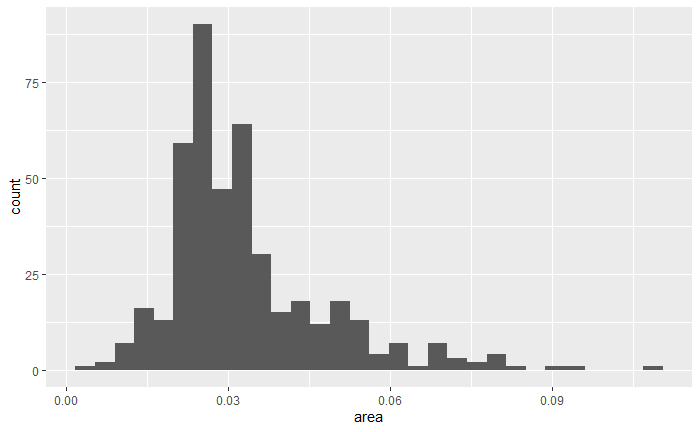

```r
ggplot(midwest, aes(x = area)) +
  geom_histogram()
```

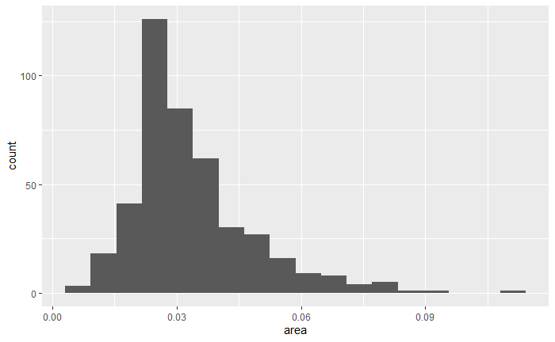

```r
ggplot(midwest, aes(x = area)) +
  geom_histogram(bins = 18)
```

Calculate a kernal density estimate of the underlying distribution:

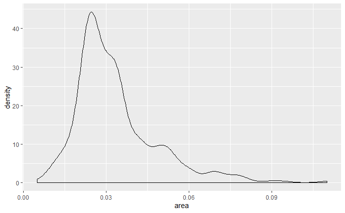

```r
ggplot(midwest, aes(x = area)) +
  geom_density()
```

## 4.7 Avoid transformations when necessary

You all ready have the proportions or counts data and don’t need ggplot to perform statistics. To turn off ggplot doing stats then enter: stat = “identity” in the geom_bar.

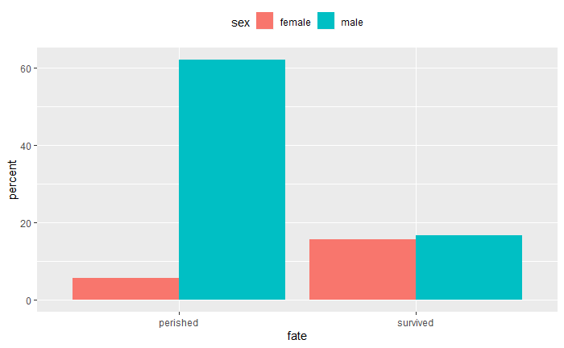

```r
ggplot(titanic, aes(x = fate, y = percent, fill = sex)) +
  geom_bar(position = "dodge", stat = "identity") +
  theme(legend.position = "top")
```